>

# Project: No-Show Appointments Data Analysis

- Introduction
- Data Wrangling
- Exploratory Data Analysis
- Conclusions

## Introduction

This data set is a collection of data from 100k medical appintments in Brazil and is focused on the question whether or not the patients show up for their appointment.The dataset gives a description of patient's age,gender,medical history,Alcoholism.It also gives the complete data about appointment details the date,whether the sms was send and finally it tells that the patients showed up for the appointment or not.

## Questions to be asked??

1.Does age plays a role in whether the patient shows up?  
2.What percentage of people didn't show up for appoitment?  
3.Which gender does show up generally?  
4.On which days of the week do most of the patients show up?  
5.Which neighborhoods have the highest number of shows/no-shows?  
6.Are sms reminders helping more patients to turn up for the appointment?  
7.Does enrolling a scholarship results in more patients showing up for appointment?

### Importing Necessary Packages

```python
import pandas as pd
import numpy as np
import matplotlib.pyplot as plt
import seaborn as sns
sns.set_style('darkgrid')

%matplotlib inline
```

## Data Wrangling

> In this section of the report, we will load in the data, check for cleanliness, and then trim and clean your dataset for analysis.

### General Properties

```python
#loading the data set
df=pd.read_csv('noshowappointments-kagglev2-may-2016.csv')
df.head(5)
```

|  | PatientId | AppointmentID | Gender | ScheduledDay | AppointmentDay | Age | Neighbourhood | Scholarship | Hipertension | Diabetes | Alcoholism | Handcap | SMS_received | No-show |
| --- | --- | --- | --- | --- | --- | --- | --- | --- | --- | --- | --- | --- | --- | --- |
| 0 | 2.987250e+13 | 5642903 | F | 2016-04-29T18:38:08Z | 2016-04-29T00:00:00Z | 62 | JARDIM DA PENHA | 0 | 1 | 0 | 0 | 0 | 0 | No |
| 1 | 5.589978e+14 | 5642503 | M | 2016-04-29T16:08:27Z | 2016-04-29T00:00:00Z | 56 | JARDIM DA PENHA | 0 | 0 | 0 | 0 | 0 | 0 | No |
| 2 | 4.262962e+12 | 5642549 | F | 2016-04-29T16:19:04Z | 2016-04-29T00:00:00Z | 62 | MATA DA PRAIA | 0 | 0 | 0 | 0 | 0 | 0 | No |
| 3 | 8.679512e+11 | 5642828 | F | 2016-04-29T17:29:31Z | 2016-04-29T00:00:00Z | 8 | PONTAL DE CAMBURI | 0 | 0 | 0 | 0 | 0 | 0 | No |
| 4 | 8.841186e+12 | 5642494 | F | 2016-04-29T16:07:23Z | 2016-04-29T00:00:00Z | 56 | JARDIM DA PENHA | 0 | 1 | 1 | 0 | 0 | 0 | No |

```python
#Checking Dimension Of dataset
df.shape
```

```
(110527, 14)
```

## There are 110527 patients and 14 columns .

```python
# Checking the diffrent datatypes and null values in data set.
df.info()
```

```
<class 'pandas.core.frame.DataFrame'>
RangeIndex: 110527 entries, 0 to 110526
Data columns (total 14 columns):
 #   Column          Non-Null Count   Dtype
---  ------          --------------   -----
 0   PatientId       110527 non-null  float64
 1   AppointmentID   110527 non-null  int64
 2   Gender          110527 non-null  object
 3   ScheduledDay    110527 non-null  object
 4   AppointmentDay  110527 non-null  object
 5   Age             110527 non-null  int64
 6   Neighbourhood   110527 non-null  object
 7   Scholarship     110527 non-null  int64
 8   Hipertension    110527 non-null  int64
 9   Diabetes        110527 non-null  int64
 10  Alcoholism      110527 non-null  int64
 11  Handcap         110527 non-null  int64
 12  SMS_received    110527 non-null  int64
 13  No-show         110527 non-null  object
dtypes: float64(1), int64(8), object(5)
memory usage: 11.8+ MB
```

## We can see that there is no null value in the data set and three diffrent data types available in our data set.We see that ScheduledDay and Appointment Day have object data type but for easiness we will convert both of them to datetime format

## Also changing the coloum mispellings and using underscore between would make it easier to work with.

```python
#summary of data set
df.describe()
```

|  | PatientId | AppointmentID | Age | Scholarship | Hipertension | Diabetes | Alcoholism | Handcap | SMS_received |
| --- | --- | --- | --- | --- | --- | --- | --- | --- | --- |
| count | 1.105270e+05 | 1.105270e+05 | 110527.000000 | 110527.000000 | 110527.000000 | 110527.000000 | 110527.000000 | 110527.000000 | 110527.000000 |
| mean | 1.474963e+14 | 5.675305e+06 | 37.088874 | 0.098266 | 0.197246 | 0.071865 | 0.030400 | 0.022248 | 0.321026 |
| std | 2.560949e+14 | 7.129575e+04 | 23.110205 | 0.297675 | 0.397921 | 0.258265 | 0.171686 | 0.161543 | 0.466873 |
| min | 3.921784e+04 | 5.030230e+06 | -1.000000 | 0.000000 | 0.000000 | 0.000000 | 0.000000 | 0.000000 | 0.000000 |
| 25% | 4.172614e+12 | 5.640286e+06 | 18.000000 | 0.000000 | 0.000000 | 0.000000 | 0.000000 | 0.000000 | 0.000000 |
| 50% | 3.173184e+13 | 5.680573e+06 | 37.000000 | 0.000000 | 0.000000 | 0.000000 | 0.000000 | 0.000000 | 0.000000 |
| 75% | 9.439172e+13 | 5.725524e+06 | 55.000000 | 0.000000 | 0.000000 | 0.000000 | 0.000000 | 0.000000 | 1.000000 |
| max | 9.999816e+14 | 5.790484e+06 | 115.000000 | 1.000000 | 1.000000 | 1.000000 | 1.000000 | 4.000000 | 1.000000 |

## We see that the minimum age is -1 in the data set ,which we will conisder infant or new born and the maxium age is above 110.

```python
#Checking For Duplicates
df.duplicated().sum()
```

```
0
```

## No duplicated values are present in the data set

```python
df.isnull().sum()
```

```
PatientId         0
AppointmentID     0
Gender            0
ScheduledDay      0
AppointmentDay    0
Age               0
Neighbourhood     0
Scholarship       0
Hipertension      0
Diabetes          0
Alcoholism        0
Handcap           0
SMS_received      0
No-show           0
dtype: int64
```

## There aren't null values present in the data set,that's great.

### Data Cleaning

We will make the changes according to observations mentioned above.

```python
#Correcting the colums spellings and introducing underscore .
new_columns=['Patient_ID','Appointment_ID','Gender','Scheduled_Day','Appointment_Date','Age','Neighbourhood','Scholarship','Hypertension','Diabetes','Alcoholism','Handicap','SMS_Recieved','No_Show']
df.columns=new_columns
df.head()
```

|  | Patient_ID | Appointment_ID | Gender | Scheduled_Day | Appointment_Date | Age | Neighbourhood | Scholarship | Hypertension | Diabetes | Alcoholism | Handicap | SMS_Recieved | No_Show |
| --- | --- | --- | --- | --- | --- | --- | --- | --- | --- | --- | --- | --- | --- | --- |
| 0 | 2.987250e+13 | 5642903 | F | 2016-04-29T18:38:08Z | 2016-04-29T00:00:00Z | 62 | JARDIM DA PENHA | 0 | 1 | 0 | 0 | 0 | 0 | No |
| 1 | 5.589978e+14 | 5642503 | M | 2016-04-29T16:08:27Z | 2016-04-29T00:00:00Z | 56 | JARDIM DA PENHA | 0 | 0 | 0 | 0 | 0 | 0 | No |
| 2 | 4.262962e+12 | 5642549 | F | 2016-04-29T16:19:04Z | 2016-04-29T00:00:00Z | 62 | MATA DA PRAIA | 0 | 0 | 0 | 0 | 0 | 0 | No |
| 3 | 8.679512e+11 | 5642828 | F | 2016-04-29T17:29:31Z | 2016-04-29T00:00:00Z | 8 | PONTAL DE CAMBURI | 0 | 0 | 0 | 0 | 0 | 0 | No |
| 4 | 8.841186e+12 | 5642494 | F | 2016-04-29T16:07:23Z | 2016-04-29T00:00:00Z | 56 | JARDIM DA PENHA | 0 | 1 | 1 | 0 | 0 | 0 | No |

```python
# Changing the datatype of Scheduled_Day,Appointment_Date from string to datetime
df.Scheduled_Day = df.Scheduled_Day.apply(np.datetime64)
```

```python
df.Appointment_Date = df.Appointment_Date.apply(np.datetime64)
df.dtypes
```

```
Patient_ID                 float64
Appointment_ID               int64
Gender                      object
Scheduled_Day       datetime64[ns]
Appointment_Date    datetime64[ns]
Age                          int64
Neighbourhood               object
Scholarship                  int64
Hypertension                 int64
Diabetes                     int64
Alcoholism                   int64
Handicap                     int64
SMS_Recieved                 int64
No_Show                     object
dtype: object
```

```python
#Extracting Day on which appointment was scheduled
df['scheduled_day_of_week'] = df.Scheduled_Day.dt.day_name()
df.head(1)
```

|  | Patient_ID | Appointment_ID | Gender | Scheduled_Day | Appointment_Date | Age | Neighbourhood | Scholarship | Hypertension | Diabetes | Alcoholism | Handicap | SMS_Recieved | No_Show | scheduled_day_of_week |
| --- | --- | --- | --- | --- | --- | --- | --- | --- | --- | --- | --- | --- | --- | --- | --- |
| 0 | 2.987250e+13 | 5642903 | F | 2016-04-29 18:38:08 | 2016-04-29 | 62 | JARDIM DA PENHA | 0 | 1 | 0 | 0 | 0 | 0 | No | Friday |

```python
#Extracting the day on which appointment day was scheduled
df['appointment_day_of_week'] = df.Appointment_Date.dt.day_name()
df.tail(1)
```

|  | Patient_ID | Appointment_ID | Gender | Scheduled_Day | Appointment_Date | Age | Neighbourhood | Scholarship | Hypertension | Diabetes | Alcoholism | Handicap | SMS_Recieved | No_Show | scheduled_day_of_week | appointment_day_of_week |
| --- | --- | --- | --- | --- | --- | --- | --- | --- | --- | --- | --- | --- | --- | --- | --- | --- |
| 110526 | 3.775115e+14 | 5629448 | F | 2016-04-27 13:30:56 | 2016-06-07 | 54 | MARIA ORTIZ | 0 | 0 | 0 | 0 | 0 | 1 | No | Wednesday | Tuesday |

```python
df.info()
```

```
<class 'pandas.core.frame.DataFrame'>
RangeIndex: 110527 entries, 0 to 110526
Data columns (total 16 columns):
 #   Column                   Non-Null Count   Dtype
---  ------                   --------------   -----
 0   Patient_ID               110527 non-null  float64
 1   Appointment_ID           110527 non-null  int64
 2   Gender                   110527 non-null  object
 3   Scheduled_Day            110527 non-null  datetime64[ns]
 4   Appointment_Date         110527 non-null  datetime64[ns]
 5   Age                      110527 non-null  int64
 6   Neighbourhood            110527 non-null  object
 7   Scholarship              110527 non-null  int64
 8   Hypertension             110527 non-null  int64
 9   Diabetes                 110527 non-null  int64
 10  Alcoholism               110527 non-null  int64
 11  Handicap                 110527 non-null  int64
 12  SMS_Recieved             110527 non-null  int64
 13  No_Show                  110527 non-null  object
 14  scheduled_day_of_week    110527 non-null  object
 15  appointment_day_of_week  110527 non-null  object
dtypes: datetime64[ns](2), float64(1), int64(8), object(5)
memory usage: 13.5+ MB
```

```python
#Converting Patient_ID from float to int value
df['Patient_ID']=df['Patient_ID'].astype('int64')
df.info()
```

```
<class 'pandas.core.frame.DataFrame'>
RangeIndex: 110527 entries, 0 to 110526
Data columns (total 16 columns):
 #   Column                   Non-Null Count   Dtype
---  ------                   --------------   -----
 0   Patient_ID               110527 non-null  int64
 1   Appointment_ID           110527 non-null  int64
 2   Gender                   110527 non-null  object
 3   Scheduled_Day            110527 non-null  datetime64[ns]
 4   Appointment_Date         110527 non-null  datetime64[ns]
 5   Age                      110527 non-null  int64
 6   Neighbourhood            110527 non-null  object
 7   Scholarship              110527 non-null  int64
 8   Hypertension             110527 non-null  int64
 9   Diabetes                 110527 non-null  int64
 10  Alcoholism               110527 non-null  int64
 11  Handicap                 110527 non-null  int64
 12  SMS_Recieved             110527 non-null  int64
 13  No_Show                  110527 non-null  object
 14  scheduled_day_of_week    110527 non-null  object
 15  appointment_day_of_week  110527 non-null  object
dtypes: datetime64[ns](2), int64(9), object(5)
memory usage: 13.5+ MB
```

```python
df.head(20)
```

|  | Patient_ID | Appointment_ID | Gender | Scheduled_Day | Appointment_Date | Age | Neighbourhood | Scholarship | Hypertension | Diabetes | Alcoholism | Handicap | SMS_Recieved | No_Show | scheduled_day_of_week | appointment_day_of_week |
| --- | --- | --- | --- | --- | --- | --- | --- | --- | --- | --- | --- | --- | --- | --- | --- | --- |
| 0 | 29872499824296 | 5642903 | F | 2016-04-29 18:38:08 | 2016-04-29 | 62 | JARDIM DA PENHA | 0 | 1 | 0 | 0 | 0 | 0 | No | Friday | Friday |
| 1 | 558997776694438 | 5642503 | M | 2016-04-29 16:08:27 | 2016-04-29 | 56 | JARDIM DA PENHA | 0 | 0 | 0 | 0 | 0 | 0 | No | Friday | Friday |
| 2 | 4262962299951 | 5642549 | F | 2016-04-29 16:19:04 | 2016-04-29 | 62 | MATA DA PRAIA | 0 | 0 | 0 | 0 | 0 | 0 | No | Friday | Friday |
| 3 | 867951213174 | 5642828 | F | 2016-04-29 17:29:31 | 2016-04-29 | 8 | PONTAL DE CAMBURI | 0 | 0 | 0 | 0 | 0 | 0 | No | Friday | Friday |
| 4 | 8841186448183 | 5642494 | F | 2016-04-29 16:07:23 | 2016-04-29 | 56 | JARDIM DA PENHA | 0 | 1 | 1 | 0 | 0 | 0 | No | Friday | Friday |
| 5 | 95985133231274 | 5626772 | F | 2016-04-27 08:36:51 | 2016-04-29 | 76 | REPÚBLICA | 0 | 1 | 0 | 0 | 0 | 0 | No | Wednesday | Friday |
| 6 | 733688164476661 | 5630279 | F | 2016-04-27 15:05:12 | 2016-04-29 | 23 | GOIABEIRAS | 0 | 0 | 0 | 0 | 0 | 0 | Yes | Wednesday | Friday |
| 7 | 3449833394123 | 5630575 | F | 2016-04-27 15:39:58 | 2016-04-29 | 39 | GOIABEIRAS | 0 | 0 | 0 | 0 | 0 | 0 | Yes | Wednesday | Friday |
| 8 | 56394729949972 | 5638447 | F | 2016-04-29 08:02:16 | 2016-04-29 | 21 | ANDORINHAS | 0 | 0 | 0 | 0 | 0 | 0 | No | Friday | Friday |
| 9 | 78124564369297 | 5629123 | F | 2016-04-27 12:48:25 | 2016-04-29 | 19 | CONQUISTA | 0 | 0 | 0 | 0 | 0 | 0 | No | Wednesday | Friday |
| 10 | 734536231958495 | 5630213 | F | 2016-04-27 14:58:11 | 2016-04-29 | 30 | NOVA PALESTINA | 0 | 0 | 0 | 0 | 0 | 0 | No | Wednesday | Friday |
| 11 | 7542951368435 | 5620163 | M | 2016-04-26 08:44:12 | 2016-04-29 | 29 | NOVA PALESTINA | 0 | 0 | 0 | 0 | 0 | 1 | Yes | Tuesday | Friday |
| 12 | 566654781423437 | 5634718 | F | 2016-04-28 11:33:51 | 2016-04-29 | 22 | NOVA PALESTINA | 1 | 0 | 0 | 0 | 0 | 0 | No | Thursday | Friday |
| 13 | 911394617215919 | 5636249 | M | 2016-04-28 14:52:07 | 2016-04-29 | 28 | NOVA PALESTINA | 0 | 0 | 0 | 0 | 0 | 0 | No | Thursday | Friday |
| 14 | 99884723334928 | 5633951 | F | 2016-04-28 10:06:24 | 2016-04-29 | 54 | NOVA PALESTINA | 0 | 0 | 0 | 0 | 0 | 0 | No | Thursday | Friday |
| 15 | 99948393975 | 5620206 | F | 2016-04-26 08:47:27 | 2016-04-29 | 15 | NOVA PALESTINA | 0 | 0 | 0 | 0 | 0 | 1 | No | Tuesday | Friday |
| 16 | 84574392942817 | 5633121 | M | 2016-04-28 08:51:47 | 2016-04-29 | 50 | NOVA PALESTINA | 0 | 0 | 0 | 0 | 0 | 0 | No | Thursday | Friday |
| 17 | 14794966191172 | 5633460 | F | 2016-04-28 09:28:57 | 2016-04-29 | 40 | CONQUISTA | 1 | 0 | 0 | 0 | 0 | 0 | Yes | Thursday | Friday |
| 18 | 17135378245248 | 5621836 | F | 2016-04-26 10:54:18 | 2016-04-29 | 30 | NOVA PALESTINA | 1 | 0 | 0 | 0 | 0 | 1 | No | Tuesday | Friday |
| 19 | 7223289184215 | 5640433 | F | 2016-04-29 10:43:14 | 2016-04-29 | 46 | DA PENHA | 0 | 0 | 0 | 0 | 0 | 0 | No | Friday | Friday |

## Exploratory Data Analysis

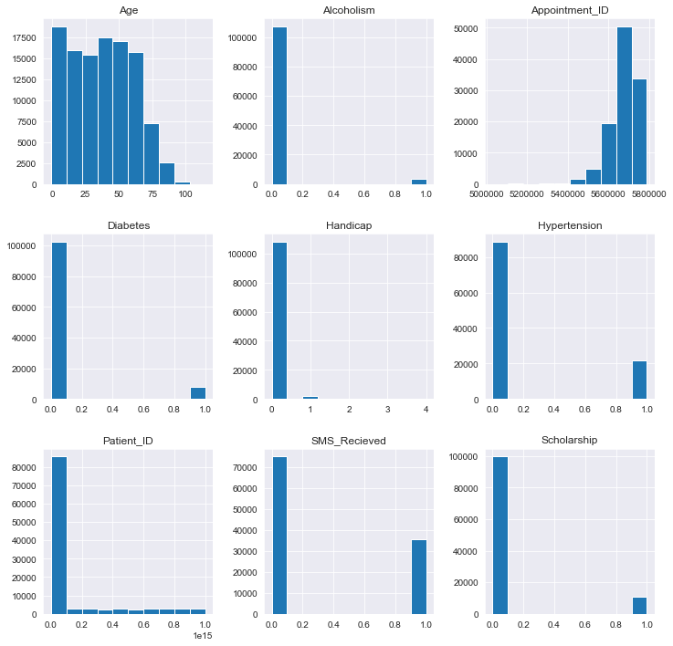

```python
df.hist(figsize=(12,12));
```

```python
#correlation between the variables
df.corr()
```

|  | Patient_ID | Appointment_ID | Age | Scholarship | Hypertension | Diabetes | Alcoholism | Handicap | SMS_Recieved |
| --- | --- | --- | --- | --- | --- | --- | --- | --- | --- |
| Patient_ID | 1.000000 | 0.004039 | -0.004139 | -0.002880 | -0.006441 | 0.001605 | 0.011011 | -0.007916 | -0.009749 |
| Appointment_ID | 0.004039 | 1.000000 | -0.019126 | 0.022615 | 0.012752 | 0.022628 | 0.032944 | 0.014106 | -0.256618 |
| Age | -0.004139 | -0.019126 | 1.000000 | -0.092457 | 0.504586 | 0.292391 | 0.095811 | 0.078033 | 0.012643 |
| Scholarship | -0.002880 | 0.022615 | -0.092457 | 1.000000 | -0.019729 | -0.024894 | 0.035022 | -0.008586 | 0.001194 |
| Hypertension | -0.006441 | 0.012752 | 0.504586 | -0.019729 | 1.000000 | 0.433086 | 0.087971 | 0.080083 | -0.006267 |
| Diabetes | 0.001605 | 0.022628 | 0.292391 | -0.024894 | 0.433086 | 1.000000 | 0.018474 | 0.057530 | -0.014550 |
| Alcoholism | 0.011011 | 0.032944 | 0.095811 | 0.035022 | 0.087971 | 0.018474 | 1.000000 | 0.004648 | -0.026147 |
| Handicap | -0.007916 | 0.014106 | 0.078033 | -0.008586 | 0.080083 | 0.057530 | 0.004648 | 1.000000 | -0.024161 |
| SMS_Recieved | -0.009749 | -0.256618 | 0.012643 | 0.001194 | -0.006267 | -0.014550 | -0.026147 | -0.024161 | 1.000000 |

1.Hypertension is related to diabetes that is patients with diabetes generally have hypertension.  
2.Age is also related with hypertension and diabetes.

## 1.Does age plays a role in whether the patient shows up?

```python
df['No_Show'].value_counts()
```

```
No     88208
Yes    22319
Name: No_Show, dtype: int64
```

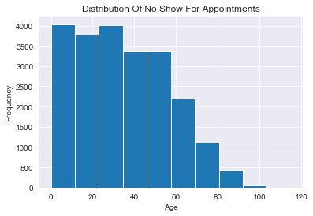

```python
df_NoShow = df[df['No_Show']  == "Yes"]
#df_NoShow.hist()
plt.hist(x='Age',data=df_NoShow)
plt.title('Distribution Of No Show For Appointments')
plt.xlabel('Age')
plt.ylabel('Frequency');
```

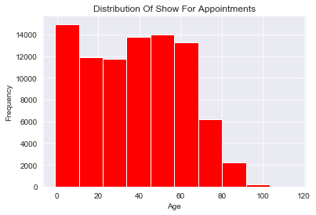

```python
df_show=df[df['No_Show'] == "No"]
plt.hist(x='Age',data=df_show,color='r')
plt.title('Distribution Of Show For Appointments')
plt.xlabel('Age')
plt.ylabel('Frequency');
```

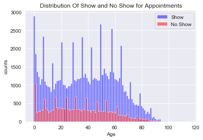

```python
#Comparision between show and no show for appointments
plt.hist(x='Age',data=df_show,bins=100,alpha=0.5,label='Show',color='b')
plt.hist(x='Age',data=df_NoShow,bins=100,alpha=0.5,label='No Show',color='r')
plt.xlabel('Age')
plt.ylabel('counts')
plt.title('Distribution Of Show and No Show for Appointments')
plt.legend()
```

For the above graphs we conclude that:  
1.The age groups of patients who generally dont show up for the appointment are between 0-20 and 20-30 age groups.  
2.Age groups between 40-60 generally show up for appointments.

### 2. What percentage of people didn't show/showed up for appoitment?

```python
df['No_Show'].value_counts()
```

```
No     88208
Yes    22319
Name: No_Show, dtype: int64
```

```python
per_noshow=df['No_Show'].value_counts()['Yes']/(df.shape[0])*100
per_noshow
```

```
20.193255946510806
```

```python
per_show=df['No_Show'].value_counts()['No']/(df.shape[0])*100
per_show
```

```
79.8067440534892
```

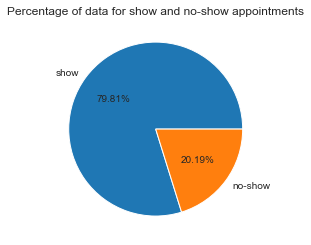

```python
#Pie Chart To represent our percentage
plt.pie(x=[per_show,per_noshow],data=df,labels=['show','no-show'],autopct='%1.2f%%')
plt.title('Percentage of data for show and no-show appointments');
```

From the above chart we can see that the 20.19% of the patients don't show up after making an appointment.

## 3. Which gender does show up generally?

```python
def print_1d_analysis(column_name, value, specific_text):
    total = len(df.index)
    total_value = (df[column_name] == value).sum()
    percent = int((total_value / total) * 100)
    text = ' This is ' + str(percent) + '% of ' + str(total) + ' records.'
    print(str(total_value) + ' ' + specific_text + text)

print_1d_analysis('Gender', 'M', 'of the appointments is for a man.')
print_1d_analysis('Gender', 'F', 'of the appointments is for a woman.')
```

```
38687 of the appointments is for a man. This is 35% of 110527 records.
71840 of the appointments is for a woman. This is 64% of 110527 records.
```

```python
df.groupby('Gender').No_Show.value_counts()
```

```
Gender  No_Show
F       No         57246
        Yes        14594
M       No         30962
        Yes         7725
Name: No_Show, dtype: int64
```

```python
def show_per(column_names, values,texts):
    total_sums = (df[column_names] == values).sum()
    show= len((df[(df[column_names] == values) & (df['No_Show'] == 'No')]))
    print(int((show / total_sums) * 100),texts)
```

```python
show_per('Gender', 'M', '% of the males who show up for the appointments')
show_per('Gender', 'F', '% of the females who show up for the appointments')
```

```
80 % of the males who show up for the appointments
79 % of the females who show up for the appointments
```

```python
def noshow_per(column_name, value,text):
    total_sum = (df[column_name] == value).sum()
    no_show = len((df[(df[column_name] == value) & (df['No_Show'] == 'Yes')]))
    print(int((no_show / total_sum) * 100),text)
```

```python
noshow_per('Gender', 'M', '% of the males who dont show  for the appointments')
noshow_per('Gender', 'F', '% of the females who dont show  for the appointments')
```

```
19 % of the males who dont show  for the appointments
20 % of the females who dont show  for the appointments
```

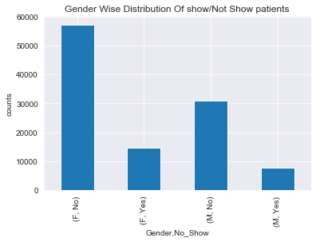

```python
df_bar=df.groupby('Gender').No_Show.value_counts()
df_bar.plot(kind='bar',title='Gender Wise Distribution Of show/Not Show patients')
plt.ylabel('counts')
```

Inference:  
1.The percentage of female patients who showed up for appointments is approximately equal to the number of male patients who showed up for the appointments.  
2.Thus,gender doesn't play a vital role in showing/missing the appoinments.

## 4.On which days of the week do most of the patients don't show up?

```python
df.groupby('appointment_day_of_week').No_Show.value_counts()
```

```
appointment_day_of_week  No_Show
Friday                   No         14982
                         Yes         4037
Monday                   No         18025
                         Yes         4690
Saturday                 No            30
                         Yes            9
Thursday                 No         13909
                         Yes         3338
Tuesday                  No         20488
                         Yes         5152
Wednesday                No         20774
                         Yes         5093
Name: No_Show, dtype: int64
```

```python
df_monday=df.groupby('appointment_day_of_week').No_Show.value_counts()['Monday']['Yes']
df_tuesday=df.groupby('appointment_day_of_week').No_Show.value_counts()['Tuesday']['Yes']
df_wednesday=df.groupby('appointment_day_of_week').No_Show.value_counts()['Wednesday']['Yes']
df_thursday=df.groupby('appointment_day_of_week').No_Show.value_counts()['Thursday']['Yes']
df_friday=df.groupby('appointment_day_of_week').No_Show.value_counts()['Friday']['Yes']
df_saturday=df.groupby('appointment_day_of_week').No_Show.value_counts()['Saturday']['Yes']

labels=['Monday','Tuesday','Wednesday','Thrusday','Friday','Saturday']
position=[1,2,3,4,5,6]
li=[df_monday,df_tuesday,df_wednesday,df_thursday,df_friday,df_saturday]
```

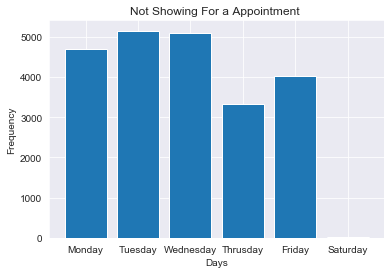

```python
plt.bar(position,height=li,tick_label=labels)
plt.title('Not Showing For a Appointment ')
plt.xlabel('Days')
plt.ylabel('Frequency')
```

We see that the majority of the patients not showing for the appointment is on Tuesday followed by Wednesday.

## 5.Which neighbourhoods have the highest number of shows/no-shows?

```python
df_neighbourhood=df.query('No_Show == "Yes"').groupby('Neighbourhood').No_Show.count()
df_neighbourhood.sort_values(ascending=False)
```

```
Neighbourhood
JARDIM CAMBURI                 1465
MARIA ORTIZ                    1219
ITARARÉ                         923
RESISTÊNCIA                     906
CENTRO                          703
                               ...
PONTAL DE CAMBURI                12
ILHA DO BOI                       3
ILHAS OCEÂNICAS DE TRINDADE       2
ILHA DO FRADE                     2
AEROPORTO                         1
Name: No_Show, Length: 80, dtype: int64
```

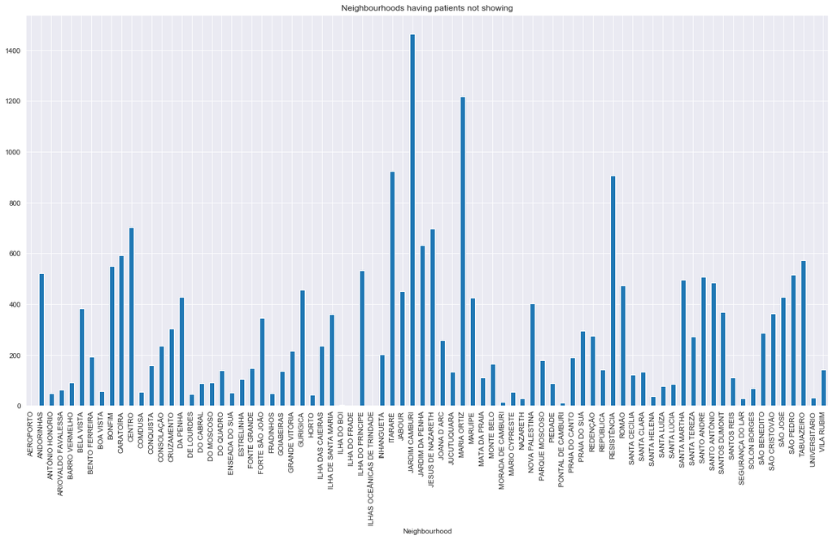

```python
df_neighbourhood.plot(kind='bar',figsize=(20, 10),title='Neighbourhoods having patients not showing')
```

```python
df_showneighbourhood=df.query('No_Show == "No"').groupby('Neighbourhood').No_Show.count()
df_showneighbourhood.sort_values(ascending=False)
```

```
Neighbourhood
JARDIM CAMBURI       6252
MARIA ORTIZ          4586
RESISTÊNCIA          3525
JARDIM DA PENHA      3246
SANTA MARTHA         2635
                     ...
PONTAL DE CAMBURI      57
ILHA DO BOI            32
ILHA DO FRADE           8
AEROPORTO               7
PARQUE INDUSTRIAL       1
Name: No_Show, Length: 80, dtype: int64
```

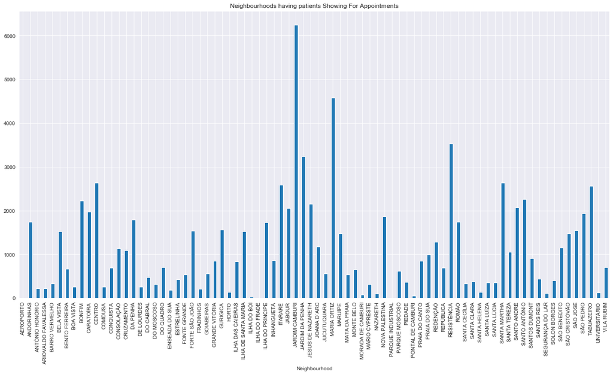

```python
#Bar Plot for neighbourhood with patients showing for appointments
df_showneighbourhood.plot(kind='bar',figsize=(20, 10),title='Neighbourhoods having patients Showing For Appointments')
```

Inference:  
1.The neighbourhood with majority of the patients not showing up for the appointment was from 'JARDIM CAMBURI' with a count of 1465.  
2.The neighbourhood with majority of the patients showing up for the appointment was from 'JARDIM CAMBURI' with a count of 6252 .

## 6.Are sms reminders helping more patients to turn up for the appointment?

```python
df.groupby('SMS_Recieved').No_Show.value_counts()
```

```
SMS_Recieved  No_Show
0             No         62510
              Yes        12535
1             No         25698
              Yes         9784
Name: No_Show, dtype: int64
```

```python
#Percentage of people who recived sms
per_smsrecieved=(df.groupby('SMS_Recieved').No_Show.count()[1])/df.shape[0]*100
per_smsrecieved
```

```
32.10256317460892
```

```python
#Percentage of people who did not recieve sms
per_smsnotrecieved=100-per_smsrecieved
per_smsnotrecieved
```

```
67.89743682539108
```

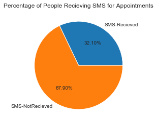

```python
# Pie Chart Representation Of Message Recieved
plt.pie(x=[per_smsrecieved,per_smsnotrecieved],labels=['SMS-Recieved','SMS-NotRecieved'],autopct='%1.2f%%')
plt.title('Percentage of People Recieving SMS for Appointments');
```

```python
#Percentage of people who didn't recieve SMS yet the showed up for the appointment
df.groupby('SMS_Recieved').No_Show.value_counts()[0]['No']/(df[df['SMS_Recieved']==  0].shape[0])*100
```

```
83.29668865347458
```

```python
#Percentage of people who recieved SMS yet the didn't showed up for the appointment
df.groupby('SMS_Recieved').No_Show.value_counts()[1]['Yes']/(df[df['SMS_Recieved']==  1].shape[0])*100
```

```
27.574544839637
```

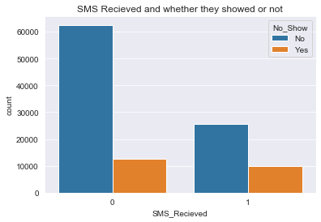

```python
#Countplot
sns.countplot(x='SMS_Recieved',hue='No_Show',data=df)
plt.title('SMS Recieved and whether they showed or not')
```

Inference:  
1.Around 67% of the patients didn't recieve message.  
2.83.3% of the patients didn't recieve message but yet showed for the appointment.  
3.27.6% of the patients who recieved sms alert for the appointment but yet didn't showed up.

## 7.Does enrolling a scholarship results in more patients showing up for appointment?

```python
df.groupby('Scholarship').No_Show.value_counts()
```

```
Scholarship  No_Show
0            No         79925
             Yes        19741
1            No          8283
             Yes         2578
Name: No_Show, dtype: int64
```

```python
df.groupby('Scholarship').No_Show.count()
```

```
Scholarship
0    99666
1    10861
Name: No_Show, dtype: int64
```

```python
per_scholarship=df.groupby('Scholarship').No_Show.count()/(df.shape[0])*100
per_scholarship
```

```
Scholarship
0    90.173442
1     9.826558
Name: No_Show, dtype: float64
```

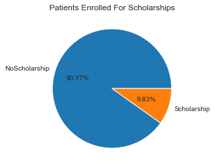

```python
#Pie Chart Of Patients Enrolling For Scholarships
plt.pie(x=[per_scholarship[0],per_scholarship[1]],labels=['NoScholarship','Scholarship'],autopct='%1.2f%%')
plt.title('Patients Enrolled For Scholarships');
```

```python
#Percentage of enrolling for scholarship and showing up for the appointment
(df.groupby('Scholarship').No_Show.value_counts()[1]['No']/(df[df['Scholarship']==1].shape[0]))*100
```

```
76.26369579228432
```

```python
#Percentage of not enrolling for scholarship and showing up for the appointment
(df.groupby('Scholarship').No_Show.value_counts()[0]['No']/(df[df['Scholarship']==0].shape[0]))*100
```

```
80.19284409929163
```

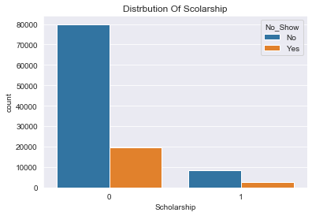

```python
sns.countplot(x='Scholarship',hue='No_Show',data=df)
plt.title('Distrbution Of Scolarship')
```

Inference:

1. Almost 90 % of the patients have not enrolled for the scholarship.
2. Among the patients who have enrolled for the scholarship 76.26% of the people showed up for the appointment which was lower as compared to the pateints not enrolling for the scholarship and showing up for the appointments .
3. 80% patients who didn't enrolled for the scholarships showed up for the appointment.

## Conclusions

#### Limitation

On sending the SMS it would be better to find the reason for not showing up ,rather than yes or no.